# Homework 07

Huanhuan Yue hyue4

Due: Friday, November 3, 11:59 PM

Please see the [homework instructions document](https://daviddalpiaz.github.io/stat430fa17/homework_policy.html) for detailed instructions and some grading notes. Failure to follow instructions will result in point reductions.

You should use the `caret` package and training pipeline to complete this homework. **Any time you use the `train()` function, first run `set.seed(1337)`.**

```r
library(caret)
library(mlbench)
library(gbm)
```

# Exercise 1 (Regression with `caret`)

**[10 points]** For this exercise we will train a number of regression models for the `Boston` data from the `MASS` package. Use `medv` as the response and all other variables as predictors. Use the test-train split given below. When tuning models and reporting cross-validated error, use 5-fold cross-validation.

```r
data(Boston, package = "MASS")
set.seed(42)
bstn_idx = createDataPartition(Boston$medv, p = 0.80, list = FALSE)
bstn_trn = Boston[bstn_idx, ]
bstn_tst = Boston[-bstn_idx, ]
```

Fit a total of five models:

- An additive linear regression
- A well tuned $k$-nearest neighbors model.
  - Do **not** scale the predictors.
  - Consider $k \in \{1, 5, 10, 15, 20, 25\}$
- Another well tuned $k$-nearest neighbors model.
  - **Do** scale the predictors.
  - Consider $k \in \{1, 5, 10, 15, 20, 25\}$
- A random forest
  - Use the default tuning parameters chosen by `caret`
- A boosted tree model
  - Use the provided tuning grid below

```r
gbm_grid = expand.grid(interaction.depth = c(1, 2, 3),
                       n.trees = (1:20) * 100,
                       shrinkage = c(0.1, 0.3),
                       n.minobsinnode = 20)
```

Provide plots of error versus tuning parameters for the two $k$-nearest neighbors models and the boosted tree model. Also provide a table that summarizes the cross-validated and test RMSE for each of the five (tuned) models.

```r
#fit models
#1. additive linear model
ln_control=trainControl(method = "cv", number = 5)
bos_ln=train(medv~., data=bstn_trn,method="lm",
  trControl=ln_control)
```

```r
#2. tuned k_nearest neighbors model
# setup knn tuning
knn_control    = trainControl(method = "cv", number = 5)
knn_tuning     = expand.grid(k = c(1,seq(5, 25, by = 5)))

# training and tune knn model/no scale
set.seed(1337)
bos_knn = train(medv ~ ., data = bstn_trn,  method = "knn",
                 trControl  = knn_control,
                 tuneGrid   = knn_tuning)
```

```r
#3. tuned k_nearest neighbors model
# setup knn tuning/scale
knn_control    = trainControl(method = "cv", number = 5)
knn_preprocess = c("center", "scale")
knn_tuning     = expand.grid(k = c(1,seq(5, 25, by = 5)))

# training and tune knn model
set.seed(1337)
bos_knn_scaled = train(medv ~ ., data = bstn_trn,  method = "knn",
                        trControl  = knn_control,
                        preProcess = knn_preprocess,
                        tuneGrid   = knn_tuning)
```

```r
#4 random forest
rf_control = trainControl(method = "cv", number = 5)

# training and tune knn model
set.seed(1337)
bos_rf = train(medv ~ ., data = bstn_trn,  method = "rf",
                trControl = rf_control)
#5 boosted tree model
set.seed(1337)

boost_control = trainControl(method = "cv", number = 5)

bos_boost=train(medv~.,data=bstn_trn,method='gbm',trControl=trainControl(method="cv",number=5),tuneGrid=gbm_grid,verbose=F)
```

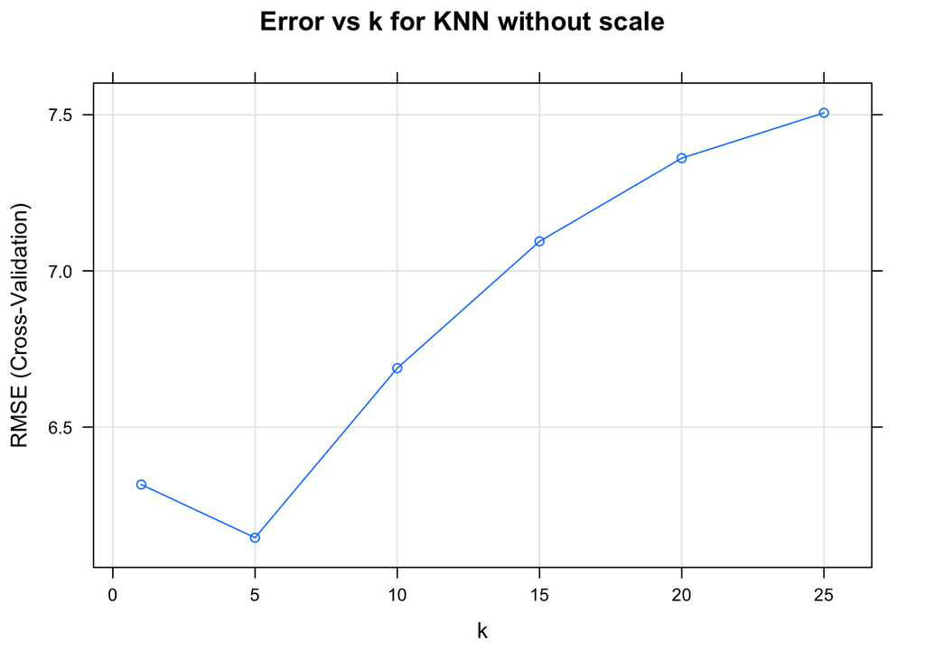

```r
plot(bos_knn,xlab="k",main="Error vs k for KNN without scale")
```

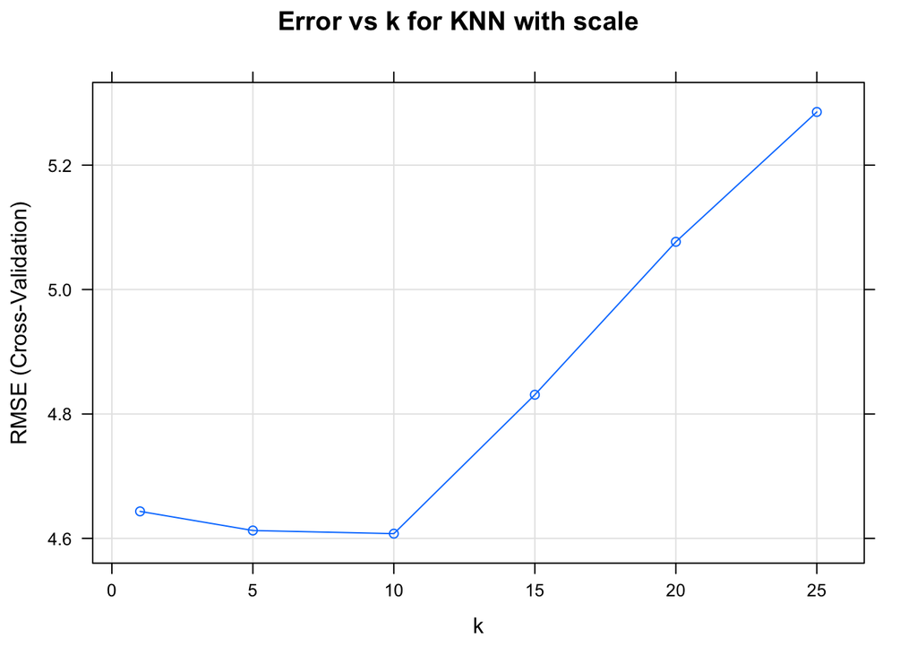

```r
plot(bos_knn_scaled,xlab="k",main="Error vs k for KNN with scale")
```

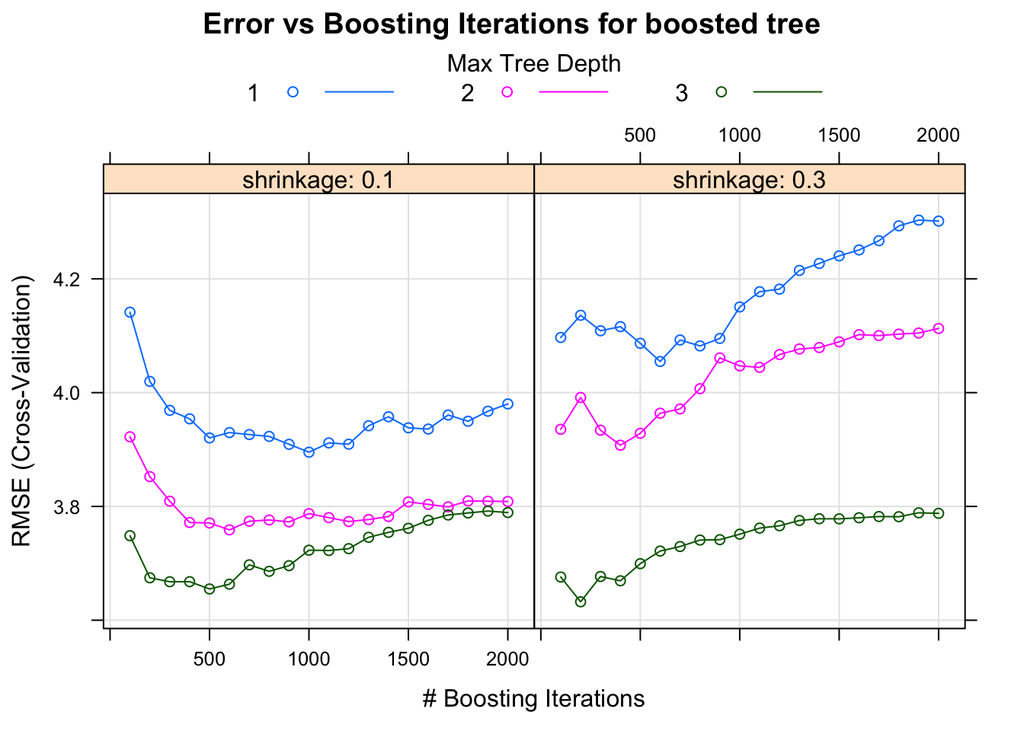

```r
plot(bos_boost,main="Error vs Boosting Iterations for boosted tree")
```

```r
test_rmse = function(actual, predicted) {
  sqrt(mean((actual - predicted) ^ 2))
}
```

```r
get_best_result = function(caret_fit) {
  best = which(rownames(caret_fit$results) == rownames(caret_fit$bestTune))
  best_result = caret_fit$results[best, ]
  rownames(best_result) = NULL
  best_result
}
calc_rmse = function(actual, predicted) {
  sqrt(mean((actual - predicted) ^ 2))
}
#get cv rmse
CV_RMSE= c(
get_best_result(bos_ln)$RMSE,
get_best_result(bos_knn)$RMSE,
get_best_result(bos_knn_scaled)$RMSE,
get_best_result(bos_rf)$RMSE,
get_best_result(bos_boost)$RMSE)
#get test rmse
TestRMSE = c(
calc_rmse(actual = bstn_tst$medv,
          predicted = predict(bos_ln, bstn_tst)),
calc_rmse(actual = bstn_tst$medv,
          predicted = predict(bos_knn, bstn_tst)),
calc_rmse(actual = bstn_tst$medv,
          predicted = predict(bos_knn_scaled, bstn_tst)),
calc_rmse(actual = bstn_tst$medv,
          predicted = predict(bos_rf, bstn_tst)),
calc_rmse(actual = bstn_tst$medv,
          predicted = predict(bos_boost, bstn_tst)))


Models = c("Additive linear regression","KNN without sacle","KNN with scale","Random Forest"," Boosted Tree")

results = data.frame(Models,CV_RMSE,TestRMSE)

colnames(results) = c("Models", "CV RMSE", "Test RMSE")

knitr::kable(results)
```

| Models | CV RMSE | Test RMSE |
| --- | --- | --- |
| Additive linear regression | 4.814634 | 4.989490 |
| KNN without sacle | 6.146077 | 6.491325 |
| KNN with scale | 4.607600 | 5.460893 |
| Random Forest | 3.277205 | 3.033097 |
| Boosted Tree | 3.632349 | 3.666415 |

# Exercise 2 (Clasification with `caret`)

**[10 points]** For this exercise we will train a number of classifiers using the training data generated below. The categorical response variable is `classes` and the remaining variables should be used as predictors. When tuning models and reporting cross-validated error, use 10-fold cross-validation.

```r
set.seed(42)
sim_trn = mlbench::mlbench.2dnormals(n = 750, cl = 5)
sim_trn = data.frame(
  classes = sim_trn$classes,
  sim_trn$x
)
```

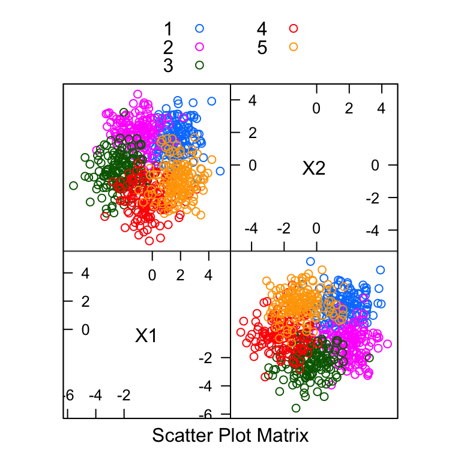

```r
caret::featurePlot(x = sim_trn[, -1],
            y = sim_trn$classes,
            plot = "pairs",
            auto.key = list(columns = 2))
```

Fit a total of four models:

- LDA
- QDA
- Naive Bayes
- Regularized Discriminant Analysis (RDA)
  - Use method `rda` with `caret` which requires the `klaR` package
  - Use the default tuning grid

Provide a plot of acuracy versus tuning parameters for the RDA model. Also provide a table that summarizes the cross-validated accuracy and their standard deviations for each of the four (tuned) models.

```r
#LDA
set.seed(1337)
lda_mod=train(
  classes~.,
  data=sim_trn,
  method="lda",
  trControl=trainControl(method="cv",number=10)
)
```

```r
#QDA
set.seed(1337)
qda_mod=train(
  classes~.,
  data=sim_trn,
  method="qda",
  trControl=trainControl(method="cv",number=10)
)
```

```r
#Naive Bayes
set.seed(1337)
nb_mod=train(
  classes~.,
  data=sim_trn,
  method="nb",
  trControl=trainControl(method="cv",number=10)
)
```

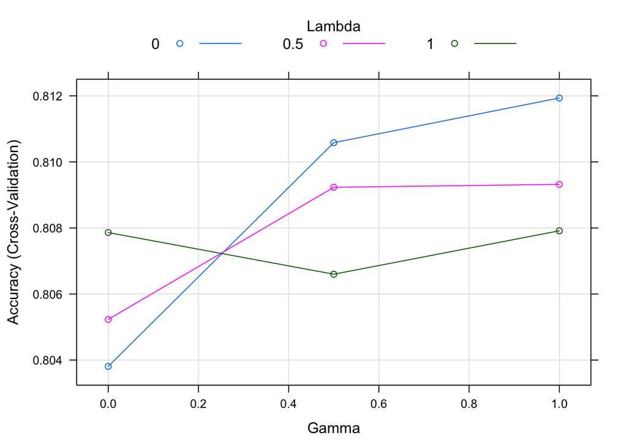

```r
library(klaR)
#RDA
set.seed(1337)
rda_mod=train(
  classes~.,
  data=sim_trn,
  method="rda",
  trControl=trainControl(method="cv",number=10)
)
plot(rda_mod)
```

```r
CV_Accuracy =c(
  get_best_result(lda_mod)$Accuracy,
  get_best_result(qda_mod)$Accuracy,
  get_best_result(nb_mod)$Accuracy,
  get_best_result(rda_mod)$Accuracy
)

Accuracy_SD = c(
  get_best_result(lda_mod)$AccuracySD,
  get_best_result(qda_mod)$AccuracySD,
  get_best_result(nb_mod)$AccuracySD,
  get_best_result(rda_mod)$AccuracySD
)

Models = c("LDA","QDA","NB","RDA")

results = data.frame(Models,CV_Accuracy,Accuracy_SD)

colnames(results) = c("Models", "CV Accuracy", "Accuracy Standard Deviation")

knitr::kable(results)
```

| Models | CV Accuracy | Accuracy Standard Deviation |
| --- | --- | --- |
| LDA | 0.8078610 | 0.0356863 |
| QDA | 0.8038074 | 0.0385323 |
| NB | 0.8118103 | 0.0366514 |
| RDA | 0.8119350 | 0.0379171 |

# Exercise 3 (Concept Checks)

**[1 point each]** Answer the following questions based on your results from the three exercises.

## Regression

**(a)** What value of $k$ is chosen for KNN without predictor scaling?

```r
bos_knn$bestTune
```

```
##   k
## 2 5
```

k=5 is chosen for KNN without predictor scaling. **(b)** What value of $k$ is chosen for KNN **with** predictor scaling?

```r
bos_knn_scaled$bestTune
```

```
##    k
## 3 10
```

k=10 is chosen for KNN **with** predictor scaling. **(c)** What are the values of the tuning parameters chosen for the boosted tree model?

```r
bos_boost$bestTune
```

```
##     n.trees interaction.depth shrinkage n.minobsinnode
## 102     200                 3       0.3             20
```

n.trees=200 is chosen for the boosted tree model. **(d)** Which method achieves the lowest cross-validated error?

Random Forest achieves the lowest cross-validated error.

**(e)** Which method achieves the lowest test error?

Random Forest achieves the lowest test error.

## Classification

**(f)** What are the values of the tuning parameters chosen for the RDA model?

```r
rda_mod$bestTune
```

```
##   gamma lambda
## 7     1      0
```

gamma=1 and lambda=0

**(g)** Based on the scatterplot, which method, LDA or QDA, do you think is *more* appropriate? Explain. QDA because the $\Sigma$k looks different for different classes and the boundaries do not look linear.

**(h)** Based on the scatterplot, which method, QDA or Naive Bayes, do you think is *more* appropriate? Explain.

Based on the scatterplot, Naive Bayes is more appropriate because x1 and x2 seems to have no correlations and independent of each other.

**(i)** Which model achieves the best cross-validated accuracy?

RDA achieves the best cross-validated accuracy.

**(j)** Do you believe the model in **(i)** is the model that should be chosen? Explain.

Yes, RDA obtains the best cross-validated accuracy